# IS 4487 Lab 10

## Outline

Repeat exercises from Lab 9, but with the *Air Quality Daily AQI* dataset.

Pull the latest "Daily AQI by County" file from this link: https://aqs.epa.gov/aqsweb/airdata/download_files.html#AQI

Your target variable is *CATEGORY*, indicating if the air is healthy. You can focus on either the entire country, split the country in regions, or focus on just one area (ex. Utah). You can reduce noise by aggregating the data to the month of season level.

Can you predict the category based on the location and time of year?

The AQI is divided into six categories:

*Air Quality Index*

| (AQI) Values | Levels of Health Concern |
| --- | --- |
| 0-50 | Good |
| 51-100 | Moderate |
| 101-150 | Unhealthy for Sensitive Groups |
| 151 to 200 | Unhealthy |
| 201 to 300 | Very Unhealthy |
| 301 to 500 | Hazardous |

## Load Libraries

➡️ Assignment Tasks

- Load any necessary libraries

```python
import pandas as pd
import numpy as np
import matplotlib.pyplot as plt
import seaborn as sns
from sklearn.linear_model import LinearRegression
from sklearn.model_selection import train_test_split
from statsmodels.tsa.seasonal import seasonal_decompose
```

## Import Data into Dataframe

➡️ Assignment Tasks

- Import data from the air quality dataset into a dataframe (in GitHub go to Labs > DataSets)
- Describe or profile the dataframe

```python
df = pd.read_csv('daily_aqi_by_county_2023.csv')
```

```python
df.describe()
```

|  | State Code | County Code | AQI | Number of Sites Reporting |
| --- | --- | --- | --- | --- |
| count | 185017.000000 | 185017.000000 | 185017.000000 | 185017.000000 |
| mean | 29.936773 | 81.188415 | 43.498397 | 1.878595 |
| std | 15.904884 | 93.001539 | 23.905791 | 2.273400 |
| min | 1.000000 | 1.000000 | 0.000000 | 1.000000 |
| 25% | 17.000000 | 23.000000 | 31.000000 | 1.000000 |
| 50% | 30.000000 | 59.000000 | 41.000000 | 1.000000 |
| 75% | 42.000000 | 107.000000 | 50.000000 | 2.000000 |
| max | 80.000000 | 810.000000 | 1695.000000 | 33.000000 |

```python
df.info()
```

```
<class 'pandas.core.frame.DataFrame'>
RangeIndex: 185017 entries, 0 to 185016
Data columns (total 10 columns):
 #   Column                     Non-Null Count   Dtype
---  ------                     --------------   -----
 0   State Name                 185017 non-null  object
 1   county Name                185017 non-null  object
 2   State Code                 185017 non-null  int64
 3   County Code                185017 non-null  int64
 4   Date                       185017 non-null  object
 5   AQI                        185017 non-null  int64
 6   Category                   185017 non-null  object
 7   Defining Parameter         185017 non-null  object
 8   Defining Site              185017 non-null  object
 9   Number of Sites Reporting  185017 non-null  int64
dtypes: int64(4), object(6)
memory usage: 14.1+ MB
```

```python
df.head()
```

|  | State Name | county Name | State Code | County Code | Date | AQI | Category | Defining Parameter | Defining Site | Number of Sites Reporting |
| --- | --- | --- | --- | --- | --- | --- | --- | --- | --- | --- |
| 0 | Alabama | Baldwin | 1 | 3 | 2023-01-10 | 35 | Good | PM2.5 | 01-003-0010 | 1 |
| 1 | Alabama | Baldwin | 1 | 3 | 2023-01-11 | 28 | Good | PM2.5 | 01-003-0010 | 1 |
| 2 | Alabama | Baldwin | 1 | 3 | 2023-01-12 | 23 | Good | PM2.5 | 01-003-0010 | 1 |
| 3 | Alabama | Baldwin | 1 | 3 | 2023-01-13 | 18 | Good | PM2.5 | 01-003-0010 | 1 |
| 4 | Alabama | Baldwin | 1 | 3 | 2023-01-14 | 20 | Good | PM2.5 | 01-003-0010 | 1 |

## Prepare Data

➡️ Assignment Tasks

- Create one dummy variable (true/false) for each of the Defining Parameter values
- Create variables for month and season
- Perform any other data cleanup needed (remove outliers, nulls, etc.)
- Select the data you would like to use in the model. If you aggregate data, you will have to decide whether to use the min, max or mean value for AQI

### Dummy Variable

```python
#dummy variable column
dummy_df = pd.get_dummies(df['Defining Parameter'])
df = pd.concat([df, dummy_df], axis=1)
```

```python
df.head()
```

|  | State Name | county Name | State Code | County Code | Date | AQI | Category | Defining Parameter | Defining Site | Number of Sites Reporting | CO | NO2 | Ozone | PM10 | PM2.5 |
| --- | --- | --- | --- | --- | --- | --- | --- | --- | --- | --- | --- | --- | --- | --- | --- |
| 0 | Alabama | Baldwin | 1 | 3 | 2023-01-10 | 35 | Good | PM2.5 | 01-003-0010 | 1 | 0 | 0 | 0 | 0 | 1 |
| 1 | Alabama | Baldwin | 1 | 3 | 2023-01-11 | 28 | Good | PM2.5 | 01-003-0010 | 1 | 0 | 0 | 0 | 0 | 1 |
| 2 | Alabama | Baldwin | 1 | 3 | 2023-01-12 | 23 | Good | PM2.5 | 01-003-0010 | 1 | 0 | 0 | 0 | 0 | 1 |
| 3 | Alabama | Baldwin | 1 | 3 | 2023-01-13 | 18 | Good | PM2.5 | 01-003-0010 | 1 | 0 | 0 | 0 | 0 | 1 |
| 4 | Alabama | Baldwin | 1 | 3 | 2023-01-14 | 20 | Good | PM2.5 | 01-003-0010 | 1 | 0 | 0 | 0 | 0 | 1 |

### Month, Year, & Season

```python
#variable for month and season
df['Date'] = pd.to_datetime(df['Date'])

# Extract month and year
df['Month'] = df['Date'].dt.month
df['Year'] = df['Date'].dt.year
df.info()
```

```
<class 'pandas.core.frame.DataFrame'>
RangeIndex: 185017 entries, 0 to 185016
Data columns (total 17 columns):
 #   Column                     Non-Null Count   Dtype
---  ------                     --------------   -----
 0   State Name                 185017 non-null  object
 1   county Name                185017 non-null  object
 2   State Code                 185017 non-null  int64
 3   County Code                185017 non-null  int64
 4   Date                       185017 non-null  datetime64[ns]
 5   AQI                        185017 non-null  int64
 6   Category                   185017 non-null  object
 7   Defining Parameter         185017 non-null  object
 8   Defining Site              185017 non-null  object
 9   Number of Sites Reporting  185017 non-null  int64
 10  CO                         185017 non-null  uint8
 11  NO2                        185017 non-null  uint8
 12  Ozone                      185017 non-null  uint8
 13  PM10                       185017 non-null  uint8
 14  PM2.5                      185017 non-null  uint8
 15  Month                      185017 non-null  int64
 16  Year                       185017 non-null  int64
dtypes: datetime64[ns](1), int64(6), object(5), uint8(5)
memory usage: 17.8+ MB
```

```python
def get_season(month):
    # Convert month to a cyclic representation to handle December as the next month after November
    month %= 12

    if month in [0, 1, 11]:
        return 'Winter'
    elif month in [2, 3, 4]:
        return 'Spring'
    elif month in [5, 6, 7]:
        return 'Summer'
    elif month in [8, 9, 10]:
        return 'Fall'
    else:
        return 'Unknown'

# Apply the function to create a new 'Season' column
df['Season'] = df['Month'].apply(get_season)

df.head()
```

|  | State Name | county Name | State Code | County Code | Date | AQI | Category | Defining Parameter | Defining Site | Number of Sites Reporting | CO | NO2 | Ozone | PM10 | PM2.5 | Month | Year | Season |
| --- | --- | --- | --- | --- | --- | --- | --- | --- | --- | --- | --- | --- | --- | --- | --- | --- | --- | --- |
| 0 | Alabama | Baldwin | 1 | 3 | 2023-01-10 | 35 | Good | PM2.5 | 01-003-0010 | 1 | 0 | 0 | 0 | 0 | 1 | 1 | 2023 | Winter |
| 1 | Alabama | Baldwin | 1 | 3 | 2023-01-11 | 28 | Good | PM2.5 | 01-003-0010 | 1 | 0 | 0 | 0 | 0 | 1 | 1 | 2023 | Winter |
| 2 | Alabama | Baldwin | 1 | 3 | 2023-01-12 | 23 | Good | PM2.5 | 01-003-0010 | 1 | 0 | 0 | 0 | 0 | 1 | 1 | 2023 | Winter |
| 3 | Alabama | Baldwin | 1 | 3 | 2023-01-13 | 18 | Good | PM2.5 | 01-003-0010 | 1 | 0 | 0 | 0 | 0 | 1 | 1 | 2023 | Winter |
| 4 | Alabama | Baldwin | 1 | 3 | 2023-01-14 | 20 | Good | PM2.5 | 01-003-0010 | 1 | 0 | 0 | 0 | 0 | 1 | 1 | 2023 | Winter |

```python
df.tail()
```

|  | State Name | county Name | State Code | County Code | Date | AQI | Category | Defining Parameter | Defining Site | Number of Sites Reporting | CO | NO2 | Ozone | PM10 | PM2.5 | Month | Year | Season |
| --- | --- | --- | --- | --- | --- | --- | --- | --- | --- | --- | --- | --- | --- | --- | --- | --- | --- | --- |
| 185012 | Wyoming | Weston | 56 | 45 | 2023-06-26 | 46 | Good | Ozone | 56-045-0003 | 1 | 0 | 0 | 1 | 0 | 0 | 6 | 2023 | Summer |
| 185013 | Wyoming | Weston | 56 | 45 | 2023-06-27 | 50 | Good | Ozone | 56-045-0003 | 1 | 0 | 0 | 1 | 0 | 0 | 6 | 2023 | Summer |
| 185014 | Wyoming | Weston | 56 | 45 | 2023-06-28 | 48 | Good | Ozone | 56-045-0003 | 1 | 0 | 0 | 1 | 0 | 0 | 6 | 2023 | Summer |
| 185015 | Wyoming | Weston | 56 | 45 | 2023-06-29 | 47 | Good | Ozone | 56-045-0003 | 1 | 0 | 0 | 1 | 0 | 0 | 6 | 2023 | Summer |
| 185016 | Wyoming | Weston | 56 | 45 | 2023-06-30 | 48 | Good | Ozone | 56-045-0003 | 1 | 0 | 0 | 1 | 0 | 0 | 6 | 2023 | Summer |

### Looking for Outliers to Filter Out

```python
df_high_aqi = df[(df['AQI'] > 500)]
```

```python
df_high_aqi.describe()
```

|  | State Code | County Code | AQI | Number of Sites Reporting | CO | NO2 | Ozone | PM10 | PM2.5 | Month | Year |
| --- | --- | --- | --- | --- | --- | --- | --- | --- | --- | --- | --- |
| count | 42.000000 | 42.000000 | 42.000000 | 42.000000 | 42.0 | 42.0 | 42.0 | 42.0 | 42.0 | 42.000000 | 42.0 |
| mean | 13.333333 | 14.238095 | 604.642857 | 3.785714 | 0.0 | 0.0 | 0.0 | 1.0 | 0.0 | 1.809524 | 2023.0 |
| std | 4.540692 | 17.657734 | 222.499967 | 4.302783 | 0.0 | 0.0 | 0.0 | 0.0 | 0.0 | 1.685492 | 0.0 |
| min | 4.000000 | 5.000000 | 505.000000 | 1.000000 | 0.0 | 0.0 | 0.0 | 1.0 | 0.0 | 1.000000 | 2023.0 |
| 25% | 8.500000 | 5.000000 | 538.250000 | 2.000000 | 0.0 | 0.0 | 0.0 | 1.0 | 0.0 | 1.000000 | 2023.0 |
| 50% | 16.000000 | 5.000000 | 544.000000 | 2.000000 | 0.0 | 0.0 | 0.0 | 1.0 | 0.0 | 1.000000 | 2023.0 |
| 75% | 16.000000 | 20.000000 | 549.750000 | 2.000000 | 0.0 | 0.0 | 0.0 | 1.0 | 0.0 | 1.000000 | 2023.0 |
| max | 16.000000 | 65.000000 | 1695.000000 | 16.000000 | 0.0 | 0.0 | 0.0 | 1.0 | 0.0 | 8.000000 | 2023.0 |

```python
df_high_aqi_2 = df[(df['AQI'] > 900)]
```

```python
df_high_aqi_2.head()
```

|  | State Name | county Name | State Code | County Code | Date | AQI | Category | Defining Parameter | Defining Site | Number of Sites Reporting | CO | NO2 | Ozone | PM10 | PM2.5 | Month | Year | Season |
| --- | --- | --- | --- | --- | --- | --- | --- | --- | --- | --- | --- | --- | --- | --- | --- | --- | --- | --- |
| 12920 | California | Mono | 6 | 51 | 2023-05-01 | 1391 | Hazardous | PM10 | 06-051-0011 | 3 | 0 | 0 | 0 | 1 | 0 | 5 | 2023 | Summer |
| 12927 | California | Mono | 6 | 51 | 2023-05-08 | 1695 | Hazardous | PM10 | 06-051-0011 | 3 | 0 | 0 | 0 | 1 | 0 | 5 | 2023 | Summer |

Could be real values, so won't remove.

### Final Columns to Use & Filtering for Utah only

```python
#select final columns for use
df_utah = df[(df['State Name'] == 'Utah')]
```

```python
filtered_df = df_utah[['AQI', 'CO', 'NO2', 'Ozone', 'PM10', 'PM2.5', 'Month', 'Year', 'Season']]
```

```python
filtered_df.head()
```

|  | AQI | CO | NO2 | Ozone | PM10 | PM2.5 | Month | Year | Season |
| --- | --- | --- | --- | --- | --- | --- | --- | --- | --- |
| 160777 | 35 | 0 | 0 | 1 | 0 | 0 | 1 | 2023 | Winter |
| 160778 | 34 | 0 | 0 | 1 | 0 | 0 | 1 | 2023 | Winter |
| 160779 | 34 | 0 | 0 | 1 | 0 | 0 | 1 | 2023 | Winter |
| 160780 | 31 | 0 | 0 | 1 | 0 | 0 | 1 | 2023 | Winter |
| 160781 | 27 | 0 | 0 | 1 | 0 | 0 | 1 | 2023 | Winter |

```python
filtered_df = pd.get_dummies(filtered_df, columns=['Season'])
```

```python
filtered_df.head()
```

|  | AQI | CO | NO2 | Ozone | PM10 | PM2.5 | Month | Year | Season_Fall | Season_Spring | Season_Summer | Season_Winter |
| --- | --- | --- | --- | --- | --- | --- | --- | --- | --- | --- | --- | --- |
| 160777 | 35 | 0 | 0 | 1 | 0 | 0 | 1 | 2023 | 0 | 0 | 0 | 1 |
| 160778 | 34 | 0 | 0 | 1 | 0 | 0 | 1 | 2023 | 0 | 0 | 0 | 1 |
| 160779 | 34 | 0 | 0 | 1 | 0 | 0 | 1 | 2023 | 0 | 0 | 0 | 1 |
| 160780 | 31 | 0 | 0 | 1 | 0 | 0 | 1 | 2023 | 0 | 0 | 0 | 1 |
| 160781 | 27 | 0 | 0 | 1 | 0 | 0 | 1 | 2023 | 0 | 0 | 0 | 1 |

## Create Regression

➡️ Assignment Tasks

- Create a simple linear regression to predict AQI based on as many variables as you can use or derive.
- Visualize the regression

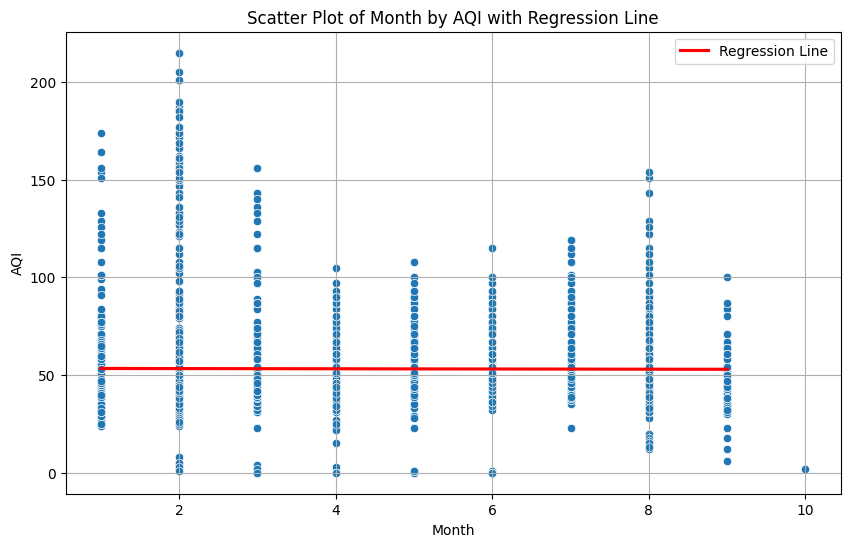

```python
# Select features and target variable
X = filtered_df[['CO', 'NO2', 'Ozone', 'PM10', 'PM2.5', 'Month', 'Year',
                 'Season_Fall', 'Season_Spring', 'Season_Summer', 'Season_Winter']]
y = filtered_df['AQI']

# Split the data into training and testing sets
X_train, X_test, y_train, y_test = train_test_split(X, y, test_size=0.2, random_state=42)

# Train the linear regression model
model = LinearRegression()
model.fit(X_train, y_train)

# Predict on the test set
y_pred = model.predict(X_test)

# Create a DataFrame with Month and AQI
data = filtered_df[['Month', 'AQI']]

# Plot the scatter plot
plt.figure(figsize=(10, 6))
sns.scatterplot(data=data, x='Month', y='AQI')

# Plot the regression line
sns.regplot(x=X_test['Month'], y=y_pred, scatter=False, color='red', label='Regression Line')

plt.xlabel('Month')
plt.ylabel('AQI')
plt.title('Scatter Plot of Month by AQI with Regression Line')
plt.legend()
plt.grid(True)
plt.show()
```

## Make a prediction

➡️ Assignment Tasks

- What would you predict the average AQI to be in the month of January?

```python
filtered_df.index = pd.to_datetime(filtered_df.index)

# Perform seasonal decomposition
result = seasonal_decompose(filtered_df['AQI'], model='additive', period=12)  # Assuming yearly seasonality

# Extract seasonal component for January
seasonal_component_january = result.seasonal[result.seasonal.index.month == 1]

# Predict AQI for January based on the average seasonal component
predicted_aqi_january = filtered_df['AQI'].mean() + seasonal_component_january.mean()

# Print the predicted average AQI for January
print("Predicted average AQI for January using seasonal decomposition:", predicted_aqi_january)
```

```
Predicted average AQI for January using seasonal decomposition: 52.543166231718885
```

## OPTIONAL: Compare Air Quality

➡️ Assignment Tasks

- Download the data from a year 20 years prior, using this website: https://aqs.epa.gov/aqsweb/airdata/download_files.html#AQI
- Append the new data to the previous dataframe
- Use the year as a variable in your regression. Is year a significant factor in predicting AQI?

```python
#import, append and create new model
```